# Week 8: Introduction to Network Statistics

While we have focused on descriptive approaches to networks and measures that can be used as variables in canonical statistical methods, we have not focused on methods that allow us to feel more confident in our descriptive assessments, nor on methods that allow us to predict aspects of the networks themselves.

The goal of gaining confidence in description and predicting aspects of networks - like the factors that lead to the existence of a tie or the factors that contribute to the structure of a network itself - are undoubtedly important, but are not easily implemented using canonical tools. For example, if we want to know whether a network is uniquely dense, we typically cannot compare to other known networks. We usually only have one to a handful of observed networks. For example, if we want to know whether the Medici marriage graph has high or low betweenness centralization, we only have the business graph for comparison. When we have a research question that engages an aspect of the network itself - e.g. factors effecting tie formation - we run into problems related to the independence of our observations. Feature of networks, such as ties, are not independent - a key assumption of canonical statistical methods like OLS regression. A person who is extroverted may have many friends affecting the entire row of friendships in a friendship adjacency matrix.

Fortunately, network scholars have developed techniques to deal with these issues. We begin with several of the most basic this week and move to more complicated models next.

## Random Network Models

Most of the approaches to network modeling that address the concerns described above - small n and autocorrelation - take advantage of simulation. By comparing the observed network to a distribution of randomly drawn networks, we can generate a null hypothesis test: Does this network significantly differ from random? We can ask: Is this network more/less dense, centralized, cohesive than we expect? Are nodes in this graph more/less constrained/unequal (by centrality) than we expect?

We’ve built simple random graph models in earlier assignments, but refresh them and compare to multiple graphs (in prior workshops we have just compared to a single graph).

There are multiple ways to build random graphs in **igraph**. You can build random graphs that feature a random distribution of nodes and edges, a graph that has small world features, and a graph that has power law features, for example. The comparison graphs should be created based on your research question. Do you think that the graph should exhibit small world characteristics? Of course, it might be best to compare across the random graphs if you are unsure.

For our purposes, we ask whether the Florentine marriage or business networks differ from random when considering small world features - average path length and transitivity?

First, we get everything loaded up and draw the two networks to remind ourselves of what’s what. We load **statnet** for several of the statistical approaches to networks, **igraph** for plotting and for some of its random network functions, **intergraph** to port to **statnet** and **ggplot** for plotting things.

```r
library(statnet)
library(igraph)
library(intergraph)
library(ggplot2)
```

Next, we load the Florentine networks. We have looked at the Medici marriage network previously. This file includes the Florentine Business, Marriage, and co-Party networks. The argument is that these the Marriage and Party networks affected the Business ties which allowed for the Medici’s consolidation of power.

```r
load("data/flonets.Rdata")
```

Let’s plot the marriage networks in **igraph** using the `plot` function with node color varying by political party.

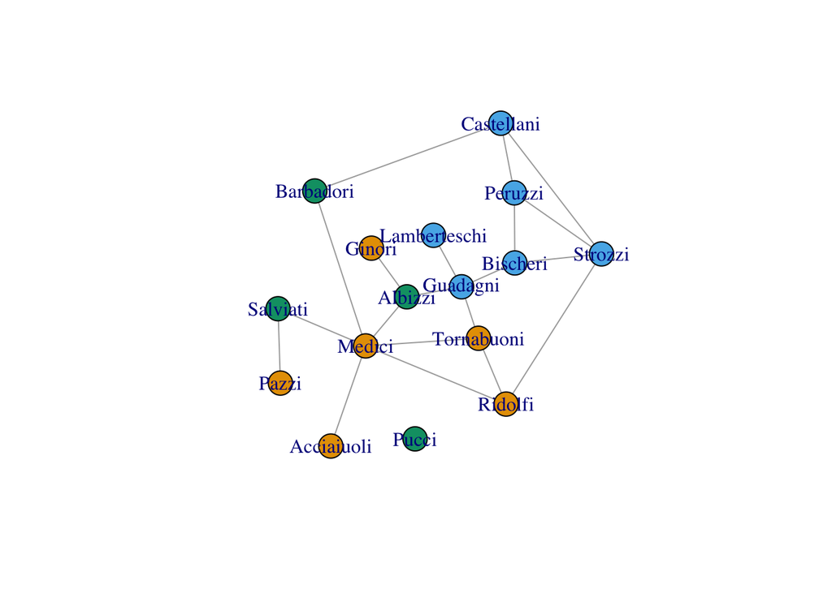

```r
plot.igraph(flomarriage, vertex.color=as.factor(V(flomarriage)$party))
```

Now we can plot the Florentine business network with node color varying by political party as well.

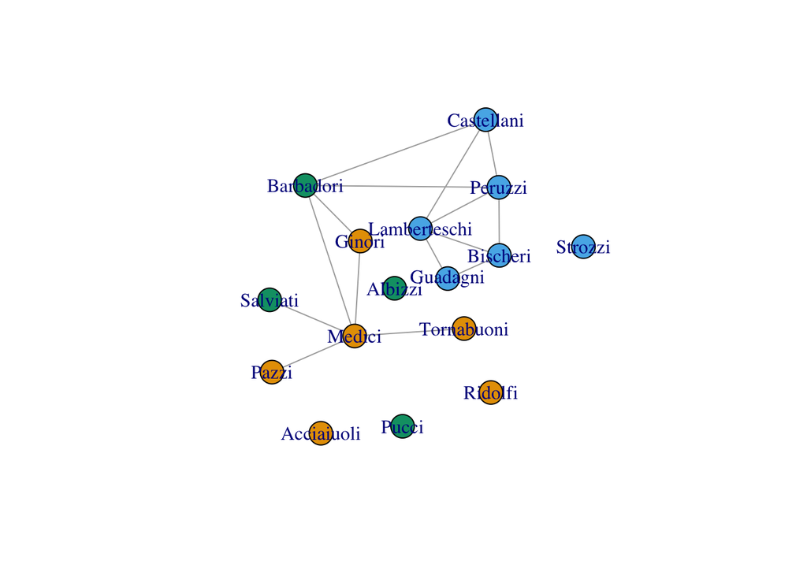

```r
plot.igraph(flobusiness, vertex.color=as.factor(V(flomarriage)$party))
```

Now we can build a bunch of random graphs. We can use a for loop to build graphs that are the same number of nodes (`gorder` function in **igraph**) and same number of edges (`gsize` function in **igraph**).

The `sample_gnm` function will produce an Erdos-Reyni random graph which is a simple random graph where edges are randomly distributed throughout the graph.

We will build 1000 of them.

```r
gs <- vector('list', 1000)

for(i in 1:1000){
  gs[[i]] <- sample_gnm(n=gorder(flomarriage), m=gsize(flomarriage))
}
```

Next, we can use lapply to build lists of the measures that we have already discussed across this list of random graphs.

For example:

Here, we create a data frame of average shortest distances for each graph by unlisting a lapply that is locating the `mean_distance` (a function from **igraph**) for each of the stored graphs.

We can then plot a histogram of the distribution of distances and compare to the observed value.

Let’s do that for average shortest path length (`mean_distance` function) and transitivity (`transitivity` function).

A small world network will have high local transitivity and short path lengths.

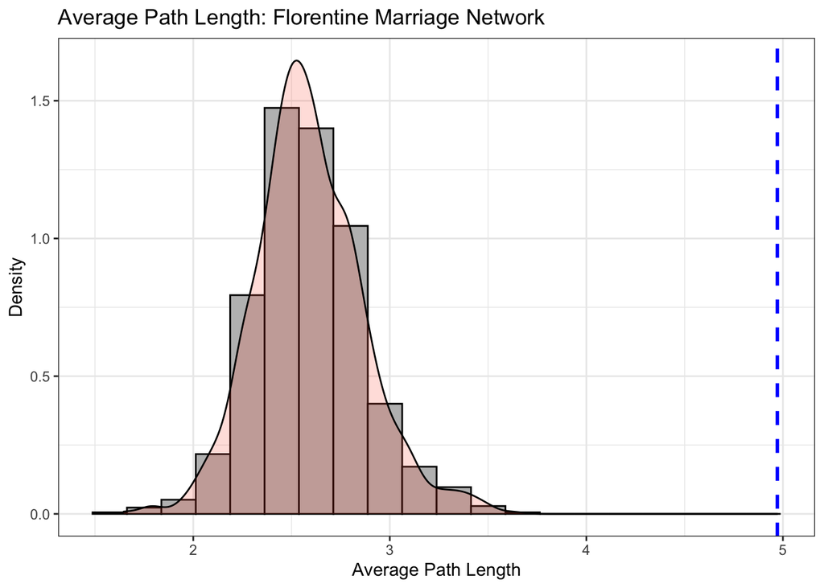

```r
library(ggplot2)

gs.dist <- data.frame(mdist = unlist(lapply(gs, mean_distance)))

ggplot(gs.dist, aes(x=mdist))+
geom_histogram(bins=20, aes(y = ..density..), color="black", fill="gray") +
     geom_density(alpha=0.2, fill="tomato") +
geom_vline(aes(xintercept=mean_distance(flomarriage)),
            color="blue", linetype="dashed", size=1) +
  labs(title="Average Path Length: Florentine Marriage Network",
        x ="Average Path Length", y = "Density") +
  theme_bw()
```

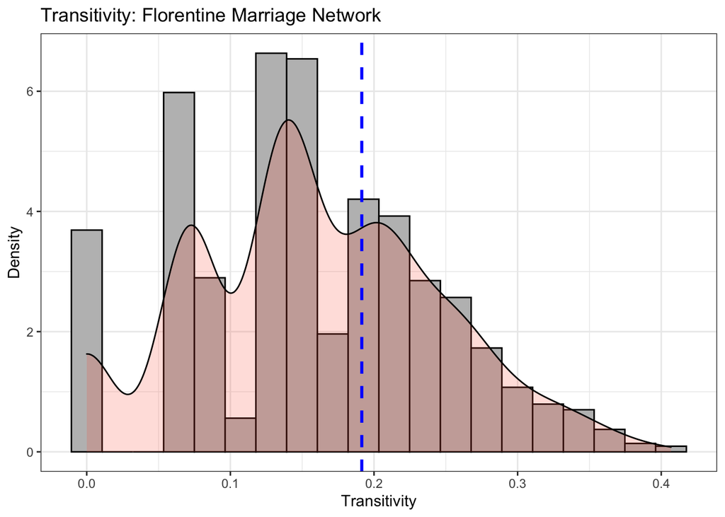

```r
gs.transitiv <- data.frame(transitiv = unlist(lapply(gs, transitivity)))

ggplot(gs.transitiv, aes(x=transitiv))+
geom_histogram(bins=20, aes(y = ..density..), color="black", fill="gray") +
     geom_density(alpha=0.2, fill="tomato") +
geom_vline(aes(xintercept=transitivity(flomarriage)),
            color="blue", linetype="dashed", size=1) +
   labs(title="Transitivity: Florentine Marriage Network",
        x ="Transitivity", y = "Density") +
  theme_bw()
```

Let’s see about the business network.

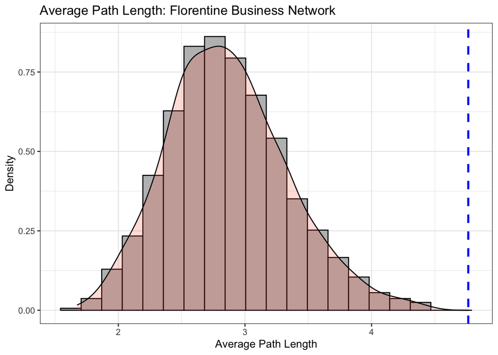

```r
gs <- vector('list', 1000)

for(i in 1:1000){
  gs[[i]] <- sample_gnm(n=gorder(flobusiness), gsize(flobusiness))
}

gs.dist <- data.frame(mdist = unlist(lapply(gs, mean_distance)))



ggplot(gs.dist, aes(x=mdist))+
geom_histogram(bins=20, aes(y = ..density..), color="black", fill="gray") +
     geom_density(alpha=0.2, fill="tomato") +
geom_vline(aes(xintercept=mean_distance(flobusiness)),
            color="blue", linetype="dashed", size=1)+
   labs(title="Average Path Length: Florentine Business Network",
        x ="Average Path Length", y = "Density") +
  theme_bw()
```

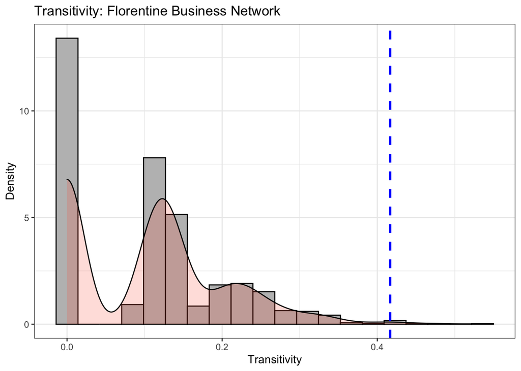

```r
gs.transitiv <- data.frame(transitiv = unlist(lapply(gs, transitivity)))

ggplot(gs.transitiv, aes(x=transitiv))+
geom_histogram(bins=20, aes(y = ..density..), color="black", fill="gray") +
     geom_density(alpha=0.2, fill="tomato") +
geom_vline(aes(xintercept=transitivity(flobusiness)),
            color="blue", linetype="dashed", size=1) +
 labs(title="Transitivity: Florentine Business Network",
        x ="Transitivity", y = "Density") +
  theme_bw()
```

## Conditional Uniform Graph Distribution Tests

Conditional uniform graphs are random graphs conditioned on a graph property of your choice - like size - these are similar to the graphs that we just generated, but using slightly randomization strategies.  
We can run all of the following from the **statnet** package which also loads **sna**. We use **intergraph** to port the **igraph** objects into the statnet/network/sna structure. Note that it makes sense to detach **igraph** prior to using **statnet** as there are a few potential overlaps.

This and the following sections are built in part from https://rpubs.com/pjmurphy/338798.

For more information about conditional uniform graph distribution tests see Butts, C. T. (2001). The complexity of social networks: theoretical and empirical findings. Social Networks, 23(1), 31-72.

First, let’s use `detach` to unload **igraph** and then `asNetwork` from **intergraph** to port the networks into **statnet**.

```r
detach("package:igraph", unload = TRUE)


fl.mar <- asNetwork(flomarriage)

fl.bus <- asNetwork(flobusiness)

fl.par <- asNetwork(floparty)
```

We can look look to see if our value is unusual relative to the random values.

Let’s see if there are differences on 1000 simulated graphs ``reps=1000`conditioned by the number of edges between the marriage and business networks.

First we use pick a graph level indicator, here transitivity (`gtrans`), and condition on the number of edges `cmode="edges""` using the `cug.test` function in **statnet**.

```r
cug.mar <- cug.test(fl.mar, gtrans, cmode="edges", reps=1000)

cug.bus <- cug.test(fl.bus, gtrans, cmode="edges", reps=1000)
```

We can build a table to see how these compare by pulling out relevant parts of the list of values that result from `cug.test`.

```r
G.Transitivity <- c(cug.mar$obs.stat, cug.bus$obs.stat)

Pct.Greater <- c(cug.mar$pgteobs, cug.bus$pgteobs)

Pct.Lower <- c(cug.mar$plteobs, cug.bus$plteobs)

comp.transitivity <- cbind(G.Transitivity, Pct.Greater, Pct.Lower)

rownames(comp.transitivity) <- c("Marital Network", "Business Network")

knitr::kable(round(comp.transitivity, 2), caption="Transitivity Comparison")
```

Transitivity Comparison

|  | G.Transitivity | Pct.Greater | Pct.Lower |
| --- | --- | --- | --- |
| Marital Network | 0.19 | 0.22 | 0.78 |
| Business Network | 0.42 | 0.00 | 1.00 |

We can see that the marital network isn’t very different from the random graphs with significant percentages both below and above the observed value. This is consistent with the random graphs constructed in **igraph** above.

Also consistent with the random graphs, we can see that the business network is significantly higher than the random distribution. None of the conditioned graphs had a higher transitivity score than the observed business network.

We can use the `plot` function in **statnet** to compare, again, this is similar to the graphs that we made above.

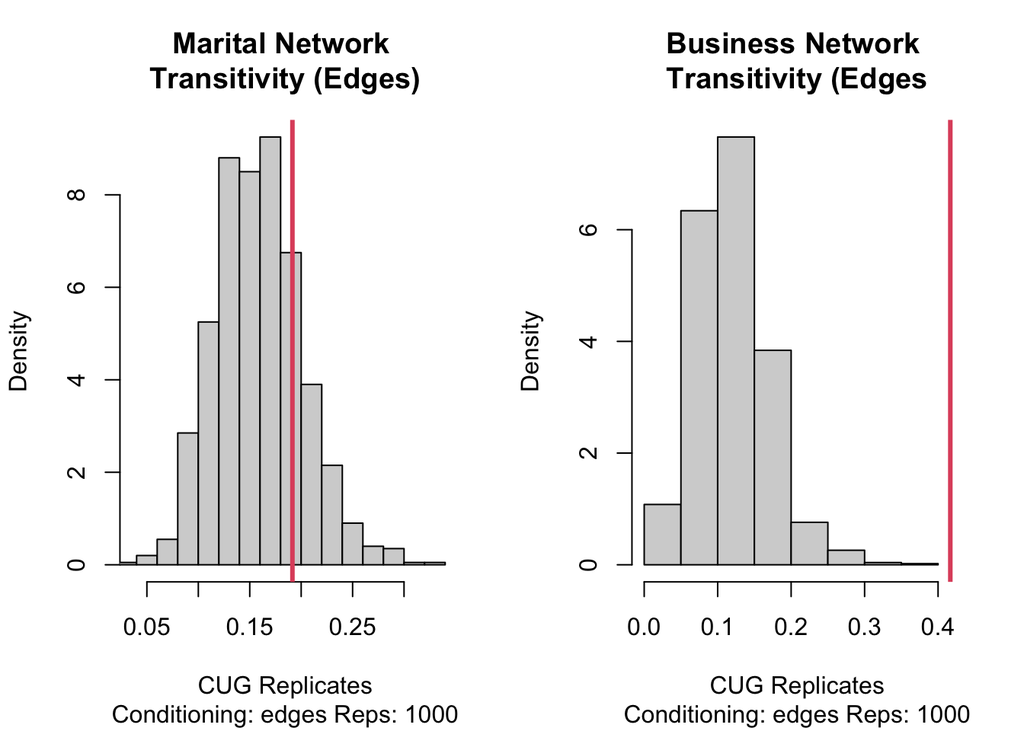

```r
par(mfrow=c(1,2))
plot(cug.mar, main="Marital Network \nTransitivity (Edges)" )
plot(cug.bus, main="Business Network \nTransitivity (Edges" )
```

This clearly shows the difference between these two networks, but we may wonder whether they are related. Specifically, we may wonder if a tie in one graph is related to a tie in the other graph.

## Dyadic Analysis: QAP Correlation

This kind of dyadic analysis is the what Quadratic Assignment Procedure was built to accomplish. The question of the relationship between two networks or matrices is a bivariate one. In this case, are business and marital ties related to one another?

QAP correlation is a statistical approach to assessing the similarity between two matrices. It enanbles one to test the relationship between two sets of nodes. These are generally considered pairwise assessments - or tie-based approaches. Therefore, they lack some of the broader considerations of more advanced alternatives.

The way that QAP works is that we compute the correlation between the original matrices, next we permute the rows and matrices of one of the matrices - or randomly relabel each cell in the matrix, in other words randomizing the ties in the original matrix and we calculate the correlation of these two matrices, repeat this permutation process hundreds or thousands of times. Last, we compare the correlation of the observed matrices to the distribution of the permuted correlations.

The `gcor` function in **statnet** finds the correlation between two adjacency matrices.

```r
gcor(fl.bus, fl.mar)
```

```
## [1] 0.3718679
```

Is this score statistically significant? Much like the CUG null hypothesis tests and simulation tests generally. We can test the graph level statistic against the null hypothesis. The test permutes (or relabels) the rows and columns of each graph and measures the test statistic (see http://fmwww.bc.edu/RePEc/nasug2001/simpson.pdf?q=qap). If the observed statistic is drawn from this distribution of permuted graphs, then we fail to reject the null.

These approaches are particularly useful for questions that involve “labeled” aspects of the graph versus structural ones. Do marriage ties, effect business ties versus is the structure of the marriage network similar to the structure of the business network. Retaining the focus on ties helps maintain that focus when discussing QAP approaches.

`qap.test` is the function in **statnet** that we can use for evaluating whether the correlation score is statistically significant (see https://search.r-project.org/CRAN/refmans/sna/html/qaptest.html for more).

For the big paper that introduced QAP, see Krackhardt, D. (1988). Predicting with networks: Nonparametric multiple regression analysis of dyadic data. Social networks, 10(4), 359-381.

```r
netcor <- qaptest(list(fl.bus, fl.mar), gcor, g1=1, g2=2, reps=1000)

summary(netcor)
```

```
##
## QAP Test Results
##
## Estimated p-values:
##  p(f(perm) >= f(d)): 0
##  p(f(perm) <= f(d)): 1
##
## Test Diagnostics:
##  Test Value (f(d)): 0.3718679
##  Replications: 1000
##  Distribution Summary:
##      Min:     -0.1690309
##      1stQ:    -0.1014185
##      Med:     -0.03380617
##      Mean:    -0.005544212
##      3rdQ:    0.03380617
##      Max:     0.3042555
```

This finding is clear in the plot as well.

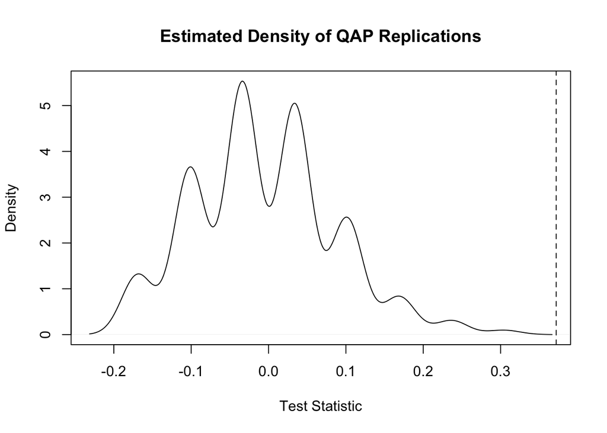

```r
plot(netcor)
```

## Dyadic Analysis: QAP Regression

We are likely to want to move beyond bivariate relationships to also consider multivariate factors predicting an outcome, such as a business tie. QAP regression allows for these multivariate considerations and performs more reliably than OLS or logistic regression with these kinds of data.

**statnet** has two functions that handle different types of data. For reference, `netlm` fits an OLS regression using QAP on a weighted network:

> netlm(y, x, intercept=TRUE, mode=“digraph”, diag=FALSE, nullhyp=c(“qap”, “qapspp”, “qapy”, “qapx”, “qapallx”, “cugtie”, “cugden”, “cuguman”, “classical”), test.statistic = c(“t-value”, “beta”), tol=1e-7, reps=1000)``

The y here is a network object and the x is a stack of network objects. So, we have to turn “independent variables” into networks. Here, we have turned party into a network, for example, by building an affiliation matrix (families x party) and using bipartite projection to make one-mode family-family network. Results of netlm are interpreted in the exact same way as canonical OLS regression.

For binary outcomes, the `netlogit` function in **statnet** is preferred. This function fits a logistic regression on an unweighted network object. The independet variables, like netlm, are also network objects.

Reading the output of `netlogit` are similar to reading a canonical logistic regression.

As the business ties in the Florentine network are unweighted, we use `netlogit` to model the effect of marital ties and party co-membership on business ties.

```r
nlog <-netlogit(fl.bus, list(fl.mar, fl.par),reps=1000)

summary(nlog)
```

```
##
## Network Logit Model
##
## Coefficients:
##             Estimate  Exp(b)     Pr(<=b) Pr(>=b) Pr(>=|b|)
## (intercept) -3.160465 0.04240601 0.000   1.000   0.000
## x1           1.874568 6.51800535 0.998   0.002   0.002
## x2           1.486959 4.42362479 0.991   0.009   0.009
##
## Goodness of Fit Statistics:
##
## Null deviance: 332.7106 on 240 degrees of freedom
## Residual deviance: 143.7447 on 237 degrees of freedom
## Chi-Squared test of fit improvement:
##   188.9659 on 3 degrees of freedom, p-value 0
## AIC: 149.7447    BIC: 160.1866
## Pseudo-R^2 Measures:
##  (Dn-Dr)/(Dn-Dr+dfn): 0.440515
##  (Dn-Dr)/Dn: 0.5679587
## Contingency Table (predicted (rows) x actual (cols)):
##
##          Actual
## Predicted     0     1
##         0   198    20
##         1    12    10
##
##  Total Fraction Correct: 0.8666667
##  Fraction Predicted 1s Correct: 0.4545455
##  Fraction Predicted 0s Correct: 0.9082569
##  False Negative Rate: 0.6666667
##  False Positive Rate: 0.05714286
##
## Test Diagnostics:
##
##  Null Hypothesis: qap
##  Replications: 1000
##  Distribution Summary:
##
##        (intercept)       x1       x2
## Min       -8.50538 -3.64215 -3.14049
## 1stQ      -7.94984 -1.14192 -0.91759
## Median    -7.76193 -0.13065  0.04343
## Mean      -7.74808 -0.03152  0.08386
## 3rdQ      -7.55439  0.89348  0.91235
## Max       -6.84104  4.85518  4.54267
```

Like logistic regression, the results include esitmates and exponentiated estimates. Both variables are statistically significant at a <.05 standard. Marital ties (x1) are a stronger predictor than party ties (x2), but having shared marital and party ties makes it far more likely that families will also share business ties.